# BIOS 611 HW4 Relational data (Chapter 13) and Strings (Chapter 14-15)

(Your full name here)

09/26/2018

(Due date: September 28 at 6 pm)

This set of exercise is mostly taken from R for Data Science by Garrett Grolemund and Hadley Wickham.

```r
library(tidyverse)
library(nycflights13)
```

# Exercise 1

1. Imagine you wanted to draw on a map the route each plane flies from its origin to its destination. What variables would you need? What tables would you need to combine?

   Answer:

I would need `origin` and `dest` in `flights`. I would also need ‘faa’, which is the IATA code of the airports, `long` and `lat`from the `airports` dataset, joining them twice as both `origin` and `dest` will be corresponded with `faa`.

2. We know that some days of the year are “special”, and fewer people than usual fly on them. How might you represent that data as a data frame? What would be the primary keys of that table? How would it connect to the existing tables?

   Answer:

I would create a dataset called `special days` with four columns, `year`, `month`, `day` and `festival`. I will join them with `year`, `month`, and `day` as keys, with the origin dataset.

# Exercise 2

1. Add a surrogate key to `flights`.

   Answer: I will create an index for each flight as `Surr_Key`.

   ```r
   Surr_Key = 1:nrow(flights)
   flights <- cbind(Surr_Key,flights)
   ```

2. Identify the keys in the following datasets

   Answer:
   1. `Lahman::Batting`, Answer: `playerID`, `yearID` and `stint`.

   ```r
   library(Lahman)
   Lahman::Batting %>%
     group_by(playerID, yearID, stint) %>%
     filter(n() > 1) %>%
     nrow()
   ```

   2. `babynames::babynames`

   Answer: `year`, `sex` and `name`.

   ```r
   library(babynames)
   babynames %>%
     group_by(year, sex, name) %>%
     filter(n() > 1) %>%
     nrow()
   ```

   3. `nasaweather::atmos` Answer: `lat`, `long`, `year` and `month`.

   ```r
   library(nasaweather)
   nasaweather::atmos %>%
     group_by(lat, long, year, month) %>%
     filter(n() > 1) %>%
     nrow()
   ```

3. Draw a diagram illustrating the connections between the `Batting`, `Master`, and `Salaries` tables in the Lahman package.  
   (A diagram does not have to be a perfect picture. It can be tables with some explanation, or it can be a scanned image of your sketch.)

   Answer:

# Exercise 3

1. Compute the average arrival delay by destination, then join on the `airports` data frame so you can show the spatial distribution of delays. Here’s an easy way to draw a map of the United States:

   ```r
   airports %>%
     semi_join(flights, c("faa" = "dest")) %>%
     ggplot(aes(lon, lat)) +
       borders("state") +
       geom_point() +
       coord_quickmap()
   ```

   (Don’t worry if you don’t understand what `semi_join()` does — you’ll learn about it next.)

   You might want to use the `colour` of the points to display the average delay for each airport.

   Answer:

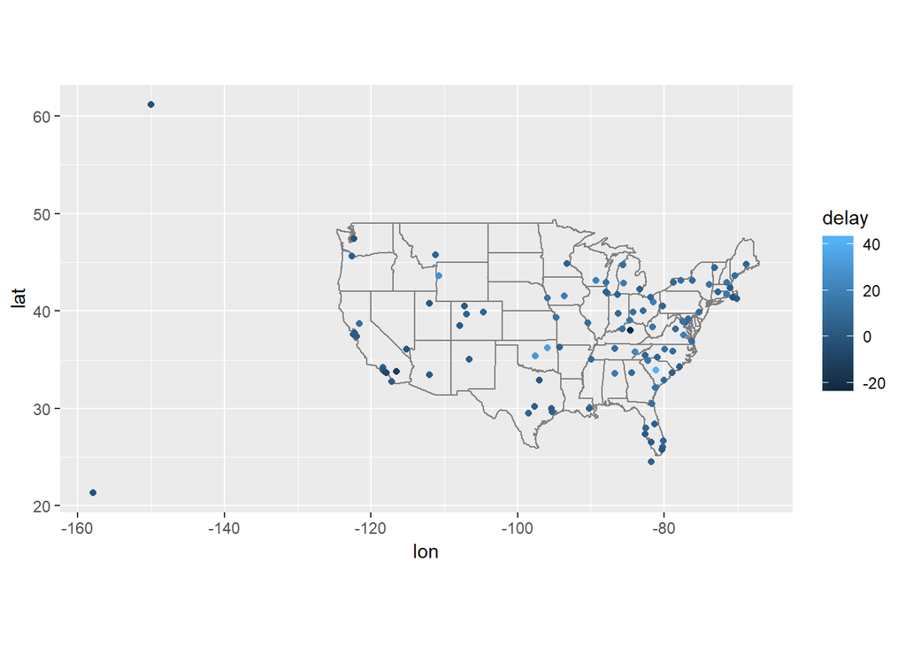

   ```r
     flights %>%
     group_by(dest) %>%
     summarise(delay = mean(arr_delay, na.rm = TRUE)) %>%
     inner_join(airports, by = c(dest = "faa")) %>%
     ggplot(aes(lon, lat, colour = delay)) +
     borders("state") +
     geom_point() +
     coord_quickmap()
   ```

2. Add the location of the origin *and* destination (i.e. the `lat` and `lon`) to `flights`.

   Answer:

   ```r
   airport_locations <- airports %>%
     select(faa, lat, lon)
   flights <- flights %>%
     left_join(
   airport_locations,
   by = c("origin" = "faa")
     ) %>%
     left_join(
   airport_locations,
   by = c("dest" = "faa"))
   ```

3. Is there a relationship between the age of a plane and its delays?

   Answer: So we first create a variable age in `planes`

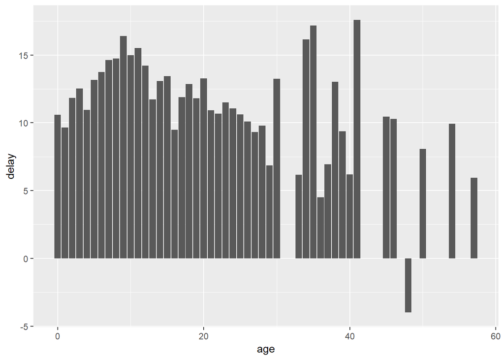

   ```r
   planes.age <- planes %>%
     mutate(age = 2013 - year) %>%
     select(tailnum, age)
   flights %>%
     left_join(planes.age, by = "tailnum") %>%
     group_by(age) %>%
     filter(!is.na(dep_delay)) %>%
     summarise(delay = mean(dep_delay)) %>%
     ggplot(aes(x = age, y = delay)) +
     geom_col()
   ```

   So It does not seem to have a significant relationship between age and delay!
4. What happened on June 13 2013? Display the spatial pattern of delays, and then use Google to cross-reference with the weather.

   Answer: So after googling that, I find out that there was storms all over the place. See what I googled below:

https://www.washingtonpost.com/news/capital-weather-gang/wp/2013/06/14/june-13-2013-severe-weather-hypestorm-or-the-real-deal/?utm_term=.6ce4dc1abd2e

[output not shown]

# Exercise 4

1. Filter flights to only show flights with planes that have flown at least 100 flights.

   Answer:

   ```r
   old.plane <- flights %>%
     group_by(tailnum) %>%
     count() %>%
     filter(n >= 100)

   flights %>%
     semi_join(old.plane, by = "tailnum")
   ```

   ```
   ##        Surr_Key year month day dep_time sched_dep_time dep_delay arr_time
   ## 1             1 2013     1   1      517            515         2      830
   ## 2             2 2013     1   1      533            529         4      850
   ## 3             4 2013     1   1      544            545        -1     1004
   ## 4             6 2013     1   1      554            558        -4      740
   ## 5             7 2013     1   1      555            600        -5      913
   ## 6             8 2013     1   1      557            600        -3      709
   ## 7             9 2013     1   1      557            600        -3      838
   ## 8            11 2013     1   1      558            600        -2      849
   ## 9            12 2013     1   1      558            600        -2      853
   ## 10           14 2013     1   1      558            600        -2      923
   ## 11           16 2013     1   1      559            559         0      702
   ## 12           17 2013     1   1      559            600        -1      854
   ## 13           18 2013     1   1      600            600         0      851
   ## 14           19 2013     1   1      600            600         0      837
   ```

   [output cut: 16654 more lines]

2. Combine `fueleconomy::vehicles` and `fueleconomy::common` to find only the records for the most common models.

   Answer:

   ```r
   library(fueleconomy)
   most.common <- common %>%
     arrange(desc(n)) %>%
     select(make, model) %>%
     head(1)
   vehicles %>%
     semi_join(most.common, by = c("make", "model"))
   ```

   ```
   ## # A tibble: 200 x 12
   ##       id make  model  year class trans drive   cyl displ fuel    hwy   cty
   ##    <int> <chr> <chr> <int> <chr> <chr> <chr> <int> <dbl> <chr> <int> <int>
   ##  1 27343 Ford  F150~  1984 Stan~ Auto~ 2-Wh~     6   4.9 Regu~    15    13
   ##  2 27344 Ford  F150~  1984 Stan~ Auto~ 2-Wh~     6   4.9 Regu~    18    14
   ##  3 27345 Ford  F150~  1984 Stan~ Manu~ 2-Wh~     6   4.9 Regu~    19    15
   ##  4 27346 Ford  F150~  1984 Stan~ Manu~ 2-Wh~     6   4.9 Regu~    22    16
   ##  5 27347 Ford  F150~  1984 Stan~ Auto~ 2-Wh~     8   5   Regu~    12    11
   ##  6 27348 Ford  F150~  1984 Stan~ Auto~ 2-Wh~     8   5   Regu~    16    12
   ##  7 27349 Ford  F150~  1984 Stan~ Manu~ 2-Wh~     8   5   Regu~    15    12
   ##  8 27350 Ford  F150~  1984 Stan~ Manu~ 2-Wh~     8   5   Regu~    17    13
   ##  9 27351 Ford  F150~  1984 Stan~ Auto~ 2-Wh~     8   5.8 Regu~    12    11
   ## 10 27352 Ford  F150~  1984 Stan~ Manu~ 2-Wh~     8   5.8 Regu~    15    11
   ## # ... with 190 more rows
   ```

3. What does `anti_join(flights, airports, by = c("dest" = "faa"))` tell you? What does `anti_join(airports, flights, by = c("faa" = "dest"))` tell you?

   Answer: `anti_join(flights, airports, by = c("dest" = "faa"))` tells me that this filters all the flight that the destination is not a FAA listed airport (which will actually be very weird). `anti_join(airports, flights, by = c("faa" = "dest"))`tells me that this will provide a list of airports that does not have a flight from NYC in 2013.
4. You might expect that there’s an implicit relationship between plane and airline, because each plane is flown by a single airline. Confirm or reject this hypothesis using the tools you’ve learned above.

   Answer: So basically, you want the plane that are flown by multiple airlines.

   ```r
   multiple.airlines <- flights %>%
     filter(!is.na(tailnum)) %>%
     count(tailnum, carrier) %>%
     count(tailnum) %>%
     filter(nn > 1)

   flights %>%
     semi_join(multiple.airlines, by = "tailnum") %>%
     select(tailnum,carrier) %>%
     distinct()
   ```

   ```
   ##    tailnum carrier
   ## 1   N978AT      FL
   ## 2   N977AT      FL
   ## 3   N935AT      FL
   ## 4   N232PQ      9E
   ## 5   N933AT      FL
   ## 6   N990AT      FL
   ## 7   N146PQ      9E
   ## 8   N153PQ      9E
   ## 9   N981AT      FL
   ## 10  N979AT      FL
   ## 11  N181PQ      9E
   ## 12  N989AT      FL
   ## 13  N176PQ      9E
   ## 14  N228PQ      9E
   ```

   [output cut: 20 more lines]

1. Given the corpus of common words in `stringr::words`, create regular expressions that find all words that:

```r
first.words <- str_extract(sentences, "[a-zA-Z]+")
```

```
1. All words ending in `ing`.
(Assign this list of words to a variable called "ing.words")
```

```r
ing.words <- c()
for (i in sentences) {
  ing <- cbind(ing.words,str_extract(i,"\\b[A-Za-z]+ing\\b"))
}
ing.words <- ing.words[!is.na(ing.words)]
```

```
1. All plurals.
(Assign this list of words to a variable called "plural.words")
```

```r
plural.words <- unique(unlist(str_extract_all(sentences, "\\b[A-Za-z]{2,}s\\b")))
```

5. Switch the first and last letters in `words`.  
   (Note `words` here refer to the the corpus of common words in `stringr::words`. Assign this newly created corpus after switching to a variable called `words.switched`)

```r
words.switched <- str_replace_all(words, "^([A-Za-z])(.*)([a-z])$", "\\3\\2\\1")
```

6. Split up a string like `"apples, pears, and bananas"` into individual components.  
   (Assign this vector of strings to a variable called `fruits`. Make sure to convert this into a vector by doing “%>% .[[1]]”)

```r
fruits <- str_split("apples, pears, and bananas", ", +(and +)?")[[1]]
```